# DA5020.A3.Jiaming.Xu

Jiaming Xu

1/31/2022

```r
knitr::opts_chunk$set(echo = TRUE)
library(tidyverse)
```

## Q1:

I experienced importing issues as tibble that as_tibble couldn’t recognize negative floats as numeric. Since there are several inconsistent nomenclature between dataset and data dictionary, it’s not easy to really determine what’s the correct type. But for “store_and_fwd_flag” variable, it’s values should be logical but it’s character as default by tibble. Therefore we need to convert it to logical if we need to use that variable. Others are correct.

For missing data, I calculate the missing frequency for each variable, and plot them as barplot for easy visualization. In fact there are several variables contain missing values. Surprisingly, ehail_fee variable is empty, no data in this column! We do want to delete it if we won’t modify it in the future analysis.

```r
tripdata_df <- read_csv("https://s3.amazonaws.com/nyc-tlc/trip+data/green_tripdata_2020-02.csv")
print("Dimensions of trip dataset:")
```

```
## [1] "Dimensions of trip dataset:"
```

```r
dim(tripdata_df)
```

```
## [1] 398632     20
```

```r
print("Missing values percentage in each variable:")
```

```
## [1] "Missing values percentage in each variable:"
```

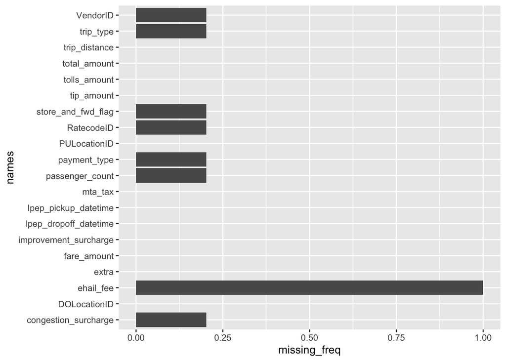

```r
tripdata_df_missing <- sapply(tripdata_df, function(x) sum( is.na(x))) / dim(tripdata_df)[1]
tibble( names = names(tripdata_df_missing), missing_freq = tripdata_df_missing) %>%
    ggplot() +
    geom_bar( mapping = aes( x = names, y = missing_freq),
              stat = "identity") +
    coord_flip()
```

## Q2:

Pick up date and drop off date both are not in 2020 Febuary shows in the console output below. There are several observations in Jan or Mar on 2020 and one in Jan on 2009.

```
## # A tibble: 18 × 22
##    VendorID lpep_pickup_datetime lpep_dropoff_datet… store_and_fwd_f… RatecodeID
##       <dbl> <dttm>               <dttm>              <chr>                 <dbl>
##  1        2 2020-01-31 20:26:37  2020-01-31 20:42:25 N                         1
##  2        2 2020-01-31 20:18:41  2020-01-31 20:37:25 N                         1
##  3        2 2009-01-01 00:47:21  2009-01-01 00:47:47 N                         1
##  4        2 2020-03-01 02:22:48  2020-03-01 02:28:48 N                         1
##  5        2 2020-03-01 02:54:27  2020-03-01 03:01:25 N                         1
##  6        2 2020-03-01 03:11:12  2020-03-01 03:33:04 N                         1
##  7        2 2020-03-01 04:06:43  2020-03-01 04:09:53 N                         1
##  8        2 2020-03-01 04:28:50  2020-03-01 04:33:35 N                         1
##  9        2 2020-03-01 04:51:15  2020-03-01 05:02:58 N                         1
## 10        2 2020-03-01 05:21:18  2020-03-01 05:24:23 N                         1
## 11        2 2020-03-01 06:34:53  2020-03-01 06:54:14 N                         1
## 12        2 2020-03-01 00:00:39  2020-03-01 00:07:30 N                         1
## 13        2 2020-03-01 00:00:04  2020-03-01 00:13:59 N                         1
## 14        2 2020-03-01 00:02:23  2020-03-01 00:22:17 N                         1
## 15        2 2020-03-01 00:01:44  2020-03-01 00:03:50 N                         1
## 16        2 2020-03-01 00:00:27  2020-03-01 00:23:01 N                         1
## 17        2 2020-03-01 00:05:12  2020-03-01 00:10:38 N                         1
## 18        2 2020-03-01 00:03:22  2020-03-01 00:20:52 N                         1
## # … with 17 more variables: PULocationID <dbl>, DOLocationID <dbl>,
## #   passenger_count <dbl>, trip_distance <dbl>, fare_amount <dbl>, extra <dbl>,
## #   mta_tax <dbl>, tip_amount <dbl>, tolls_amount <dbl>, ehail_fee <lgl>,
## #   improvement_surcharge <dbl>, total_amount <dbl>, payment_type <dbl>,
## #   trip_type <dbl>, congestion_surcharge <dbl>, pick_up_month <chr>,
## #   drop_off_month <chr>
```

Examine if there are abnormal values in the “RateCodeID” column, we can see there is code 99 in the column, but should be only 1 to 6 in the data dictionary. Therefore any values with code 99 should be removed or defined.

```r
tripdata_df %>%
    pull( RatecodeID) %>%
    unique()
```

```
## [1]  1  4  5  3  2  6 99 NA
```

There are also several observations with negative total_amount, the total amount charged to passengers. Does not include cash tips, which are abnormal.

```r
tripdata_df %>%
    filter( 0 > total_amount) %>%
    select( VendorID, passenger_count, total_amount)
```

```
## # A tibble: 1,152 × 3
##    VendorID passenger_count total_amount
##       <dbl>           <dbl>        <dbl>
##  1        2               1         -4.8
##  2        2               1        -25
##  3        2               1         -3.8
##  4        2               1         -5.3
##  5        2               1         -5.8
##  6        2               1         -4.3
##  7        2               1         -3.8
##  8        2               1         -5.8
##  9        2               2         -3.8
## 10        2               1        -52.8
## # … with 1,142 more rows
```

Also, there’s no value in ehail_fee column, we should drop it for analysis.

```r
sum(!is.na(tripdata_df$ehail_fee))
```

```
## [1] 0
```

## Q3:

The histogram plot shows only one visible bar with more than 30k data, therefore the data is highly skewed. This means there are several very long trip distance in this dataset. Take logarithm 10 to trip_distance for a better visualization, it looks like the normal distribution, but the x axis is actually based on log10. I also list first 20 longest trip distance in this dataset, 10 trip distances longer than 10k.

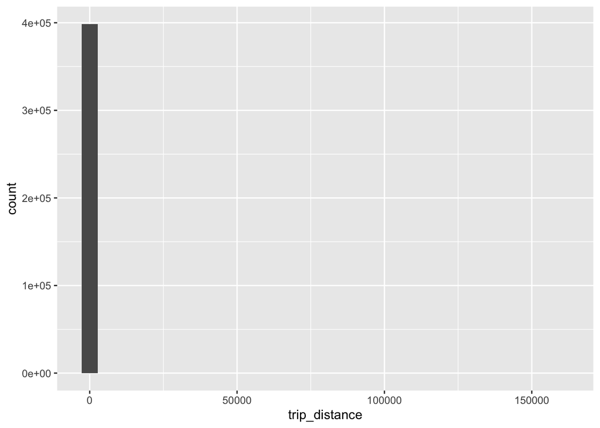

```r
tripdata_df %>%
    select( trip_distance) %>%
    drop_na() %>%
    ggplot() +
        geom_histogram( mapping = aes( trip_distance))
```

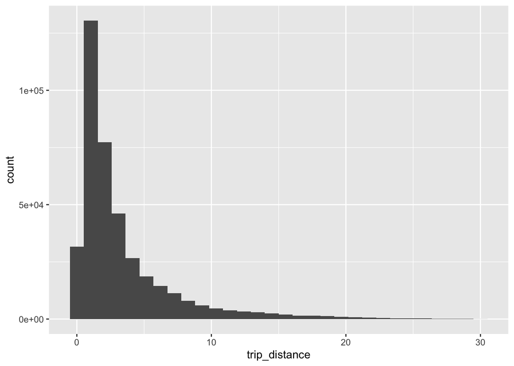

```r
tripdata_df %>%
    mutate( z = (trip_distance - mean(trip_distance) / sd(trip_distance))) %>%
    filter( abs(z) < 30) %>%
    select( trip_distance) %>%
    ggplot() +
        geom_histogram( mapping = aes( trip_distance))
```

```r
sort( tripdata_df$trip_distance, decreasing = TRUE) [1:20]
```

```
##  [1] 159907.16 122181.83 117195.07  37266.59  34695.14  29890.02  24904.41
##  [8]  20444.29  12467.88  12392.84   8834.64   8476.68   6264.50   5388.10
## [15]   4566.44    108.83    107.22    101.13     89.66     64.92
```

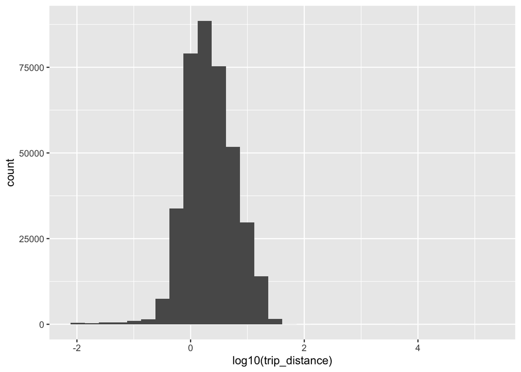

```r
tripdata_df %>%
    select( trip_distance) %>%
    drop_na() %>%
    ggplot() +
        geom_histogram( mapping = aes( log10(trip_distance)))
```

## Q4:

```r
tripdata_outliers <- tripdata_df %>%
    mutate( z = ((tip_amount - mean(tip_amount)) / sd(tip_amount))) %>%
    filter( abs(z) > 3)

tripdata_tip_clean <- tripdata_df %>%
    mutate( z = ((tip_amount - mean(tip_amount)) / sd(tip_amount))) %>%
    filter( abs(z) <= 3)

tripdata_tip_clean
```

```
## # A tibble: 394,884 × 21
##    VendorID lpep_pickup_datetime lpep_dropoff_datet… store_and_fwd_f… RatecodeID
##       <dbl> <dttm>               <dttm>              <chr>                 <dbl>
##  1        2 2020-02-01 00:10:25  2020-02-01 00:14:34 N                         1
##  2        2 2020-02-01 00:16:59  2020-02-01 00:21:35 N                         1
##  3        2 2020-02-01 00:19:31  2020-02-01 00:25:29 N                         1
##  4        2 2020-02-01 00:43:52  2020-02-01 00:48:58 N                         1
##  5        2 2020-02-01 00:32:53  2020-02-01 00:35:19 N                         1
##  6        2 2020-02-01 00:04:36  2020-02-01 00:10:09 N                         1
##  7        2 2020-02-01 00:49:36  2020-02-01 01:07:27 N                         1
##  8        2 2020-02-01 00:21:08  2020-02-01 00:28:16 N                         1
##  9        2 2020-02-01 00:05:16  2020-02-01 00:16:25 N                         1
## 10        2 2020-02-01 00:59:48  2020-02-01 01:06:26 N                         1
## # … with 394,874 more rows, and 16 more variables: PULocationID <dbl>,
## #   DOLocationID <dbl>, passenger_count <dbl>, trip_distance <dbl>,
## #   fare_amount <dbl>, extra <dbl>, mta_tax <dbl>, tip_amount <dbl>,
## #   tolls_amount <dbl>, ehail_fee <lgl>, improvement_surcharge <dbl>,
## #   total_amount <dbl>, payment_type <dbl>, trip_type <dbl>,
## #   congestion_surcharge <dbl>, z <dbl>
```

## Q5:

I made boxplot to visualize the relationship between payment method and tips amount. In the figure below we can see credit card users generally paid more tips than other payment methods.

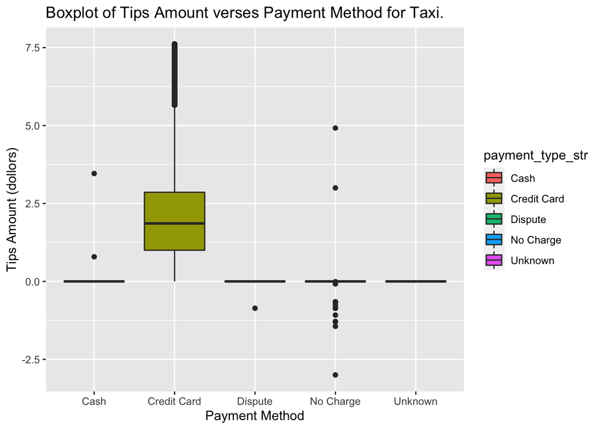

```r
payment_type_dict = c("Credit Card", "Cash", "No Charge", "Dispute", "Unknown", "Voided Trip")
tripdata_tip_clean %>%
    mutate( payment_type_str = sapply(tripdata_tip_clean $payment_type,
                                      function(i) payment_type_dict[i])) %>%
    select( payment_type_str, tip_amount) %>%
    drop_na() %>%
    ggplot( ) +
    geom_boxplot( mapping = aes( y = tip_amount, x = payment_type_str,
                                 fill = payment_type_str)) +
    labs( x = "Payment Method", y = "Tips Amount (dollors)",
          title = "Boxplot of Tips Amount verses Payment Method for Taxi.")
```

## Q6:

For numerical variables, we can use either: (1) make prediction (2) general average (3) average in category (4) ignore these overvations to replace missing values.